| title: “Veeraraghavan et al 2017” |
| --- |
| author: “James D. Brenton” |
| date: “18 March 2017” |
| output: html_document |

Load in clinical data.

## Simple data exploration

Total number of patients

```
## # A tibble: 1 × 1
##       n
##   <int>
## 1    84
```

Are there any duplicate tcga.id?

```
## # A tibble: 1 × 1
##       n
##   <int>
## 1    84
```

How many in each group?

```
## # A tibble: 2 × 3
##   institution.bin     n rel.freq
##             <chr> <int>    <dbl>
## 1           MSKCC    46       55
## 2            TCIA    38       45
```

What was follow up? (NO DATA IN DATA FILE) Follow-up months added Field - Follow.up.mos – Harini Veeraraghavan

How many platinum sensitive vs. resistant?

```
## Source: local data frame [6 x 4]
## Groups: institution.bin [2]
##
##   institution.bin platinum.resistant     n rel.freq
##             <chr>              <lgl> <int>    <dbl>
## 1           MSKCC              FALSE    35     76.1
## 2           MSKCC               TRUE     9     19.6
## 3           MSKCC                 NA     2      4.3
## 4            TCIA              FALSE    17     44.7
## 5            TCIA               TRUE     7     18.4
## 6            TCIA                 NA    14     36.8
```

Were there stage differences?

```
## Source: local data frame [5 x 4]
## Groups: institution.bin [2]
##
##   institution.bin stage     n rel.freq
##             <chr> <int> <int>    <dbl>
## 1           MSKCC     3    31       67
## 2           MSKCC     4    15       33
## 3            TCIA     2     4       11
## 4            TCIA     3    29       76
## 5            TCIA     4     5       13
```

Were there differences in tumour volume between the cohorts?

```
## # A tibble: 2 × 6
##   institution.bin  min_   Q1_ median_   Q3_  max_
##             <chr> <dbl> <dbl>   <dbl> <dbl> <dbl>
## 1           MSKCC   7.4    65     122   232   744
## 2            TCIA   5.2   153     328   601  2585
```

Plot the volume distributions.

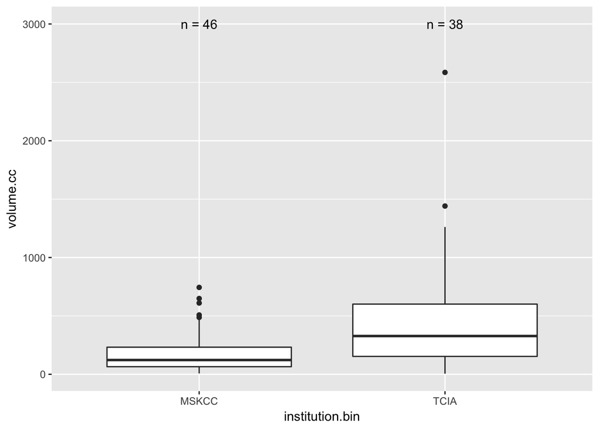

Non-parametric test for volume distributions.

```
##   statistic p.value                 method alternative
## 1       514   0.001 Wilcoxon rank sum test   two.sided
```

Were there differences in the number of sites (ROI) between the cohorts?

```
## # A tibble: 2 × 6
##   institution.bin  min_   Q1_ median_   Q3_  max_
##             <chr> <int> <dbl>   <dbl> <dbl> <int>
## 1           MSKCC     2   5.2       7     9    12
## 2            TCIA     2   3.0       4     4     7
```

Plot the ROI counts.

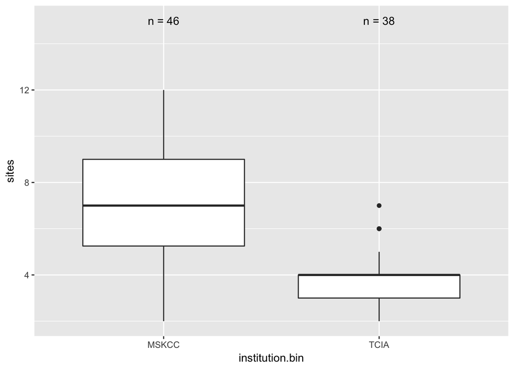

Non-parametric test for ROI.

```
##   statistic p.value                                            method
## 1      1460 1.1e-07 Wilcoxon rank sum test with continuity correction
##   alternative
## 1   two.sided
```

## Survival analysis

What is OS in the two cohorts?

```
## Source: local data frame [2 x 10]
## Groups: institution.bin [2]
##
##   institution.bin records n.max n.start events rmean rmean.std.error
##             <chr>   <dbl> <dbl>   <dbl>  <dbl> <dbl>           <dbl>
## 1           MSKCC      46    46      46     29    73             6.1
## 2            TCIA      38    38      38     22    51             6.9
## # ... with 3 more variables: median <dbl>, conf.low <dbl>, conf.high <dbl>
```

Plot comparison of OS.

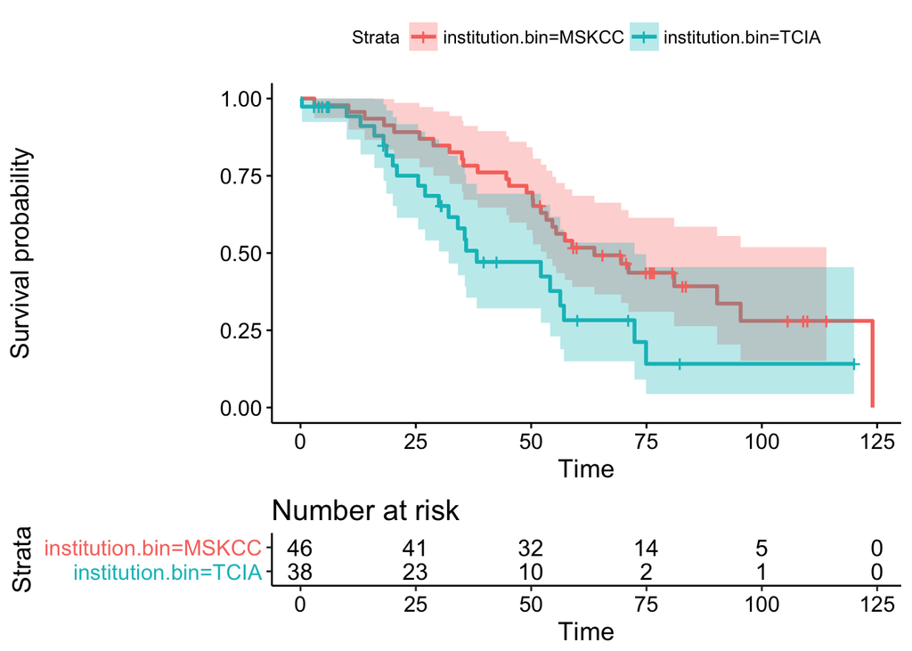

Plot comparison of OS by the clusters extracted using ISTH measures in the two datasets. OS for MSKCC dataset

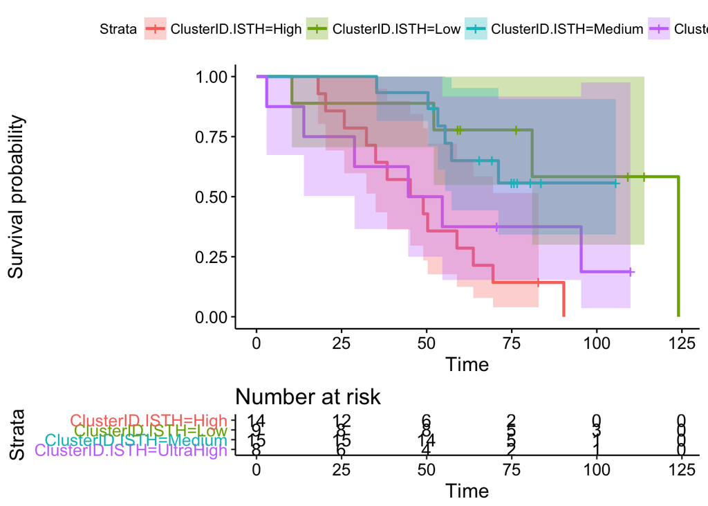

OS for TCIA dataset

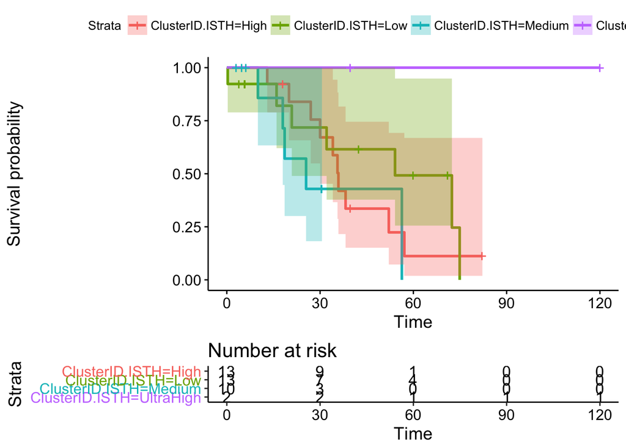

What is PFS in the two cohorts?

```
## Source: local data frame [2 x 10]
## Groups: institution.bin [2]
##
##   institution.bin records n.max n.start events rmean rmean.std.error
##             <chr>   <dbl> <dbl>   <dbl>  <dbl> <dbl>           <dbl>
## 1           MSKCC      46    46      46     44    20             1.7
## 2            TCIA      38    38      38     19    37             5.5
## # ... with 3 more variables: median <dbl>, conf.low <dbl>, conf.high <dbl>
```

Plot comparison of PFS. The data for TCIA is has wide confidence intervals and is probably not usable.

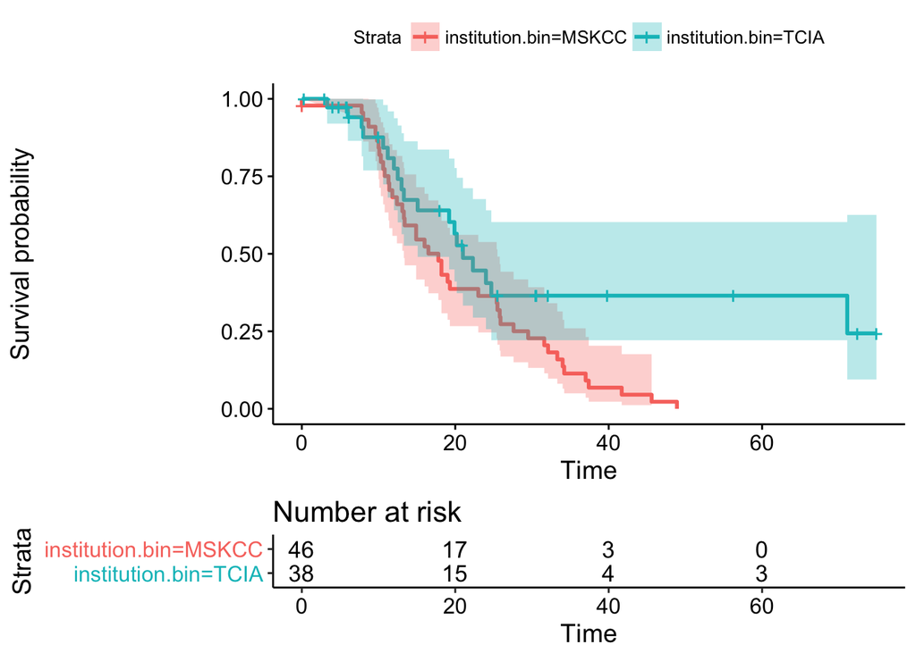

PFS for MSKCC dataset

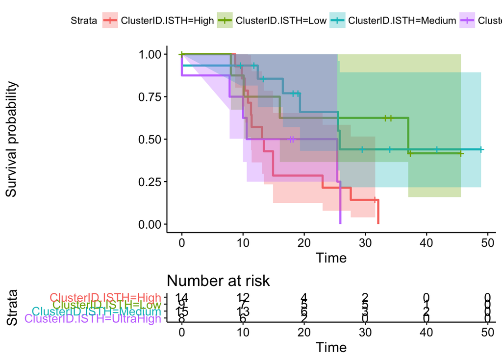

PFS for TCIA dataset

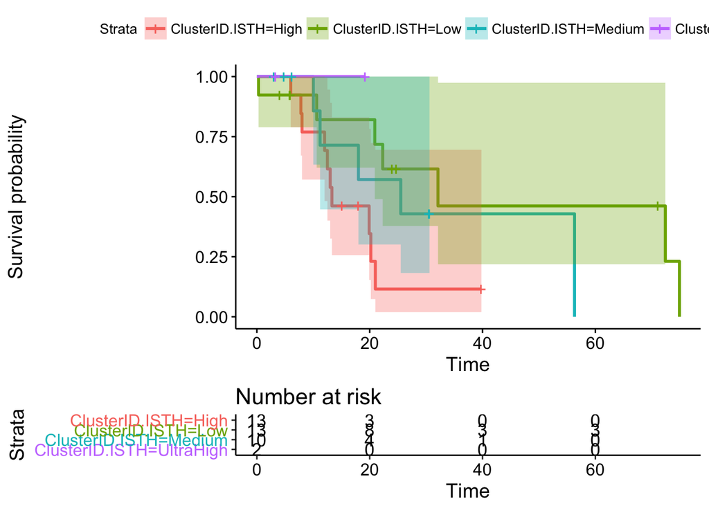

What are main factors for OS from Cox proportional hazard analysis?

```
## Source: local data frame [10 x 6]
## Groups: institution.bin [2]
##
##    institution.bin                   term estimate p.value conf.low
##              <chr>                  <chr>    <dbl>   <dbl>    <dbl>
## 1            MSKCC platinum.resistantTRUE      3.6   0.028     1.15
## 2            MSKCC                    age      1.0   0.094     0.99
## 3            MSKCC                  stage      2.2   0.124     0.80
## 4            MSKCC       residual.disease      1.4   0.210     0.84
## 5            MSKCC              volume.cc      1.0   0.385     1.00
## 6             TCIA                  stage      6.8   0.019     1.36
## 7             TCIA       residual.disease      1.9   0.049     1.00
## 8             TCIA                    age      1.1   0.126     0.98
## 9             TCIA              volume.cc      1.0   0.223     1.00
## 10            TCIA platinum.resistantTRUE      2.3   0.267     0.53
## # ... with 1 more variables: conf.high <dbl>
```

What are main factors for PFS from Cox proportional hazard analysis?

```
## Source: local data frame [10 x 6]
## Groups: institution.bin [2]
##
##    institution.bin                   term estimate  p.value conf.low
##              <chr>                  <chr>    <dbl>    <dbl>    <dbl>
## 1            MSKCC platinum.resistantTRUE    19.69 0.000009     5.28
## 2            MSKCC                    age     1.04 0.020219     1.01
## 3            MSKCC                  stage     1.61 0.247087     0.72
## 4            MSKCC              volume.cc     1.00 0.262295     1.00
## 5            MSKCC       residual.disease     1.12 0.568430     0.75
## 6             TCIA platinum.resistantTRUE     2.78 0.200774     0.58
## 7             TCIA                  stage     1.61 0.473787     0.44
## 8             TCIA       residual.disease     1.17 0.579656     0.66
## 9             TCIA                    age     0.98 0.610621     0.92
## 10            TCIA              volume.cc     1.00 0.655920     1.00
## # ... with 1 more variables: conf.high <dbl>
```

## Correlation analysis

Convert wide table into long format.

Are image.metrics correlated with volume?

```
## Source: local data frame [7 x 9]
## Groups: image.metric [7]
##
##   image.metric estimate statistic p.value parameter conf.low conf.high
##          <chr>    <dbl>     <dbl>   <dbl>     <int>    <dbl>     <dbl>
## 1     clu.diss   -0.028     -0.25    0.80        82    -0.24     0.188
## 2      entropy   -0.029     -0.26    0.79        82    -0.24     0.186
## 3         c.se   -0.057     -0.52    0.61        82    -0.27     0.159
## 4      clu.dev   -0.071     -0.64    0.52        82    -0.28     0.146
## 5       energy   -0.112     -1.02    0.31        82    -0.32     0.105
## 6  homogeneity   -0.181     -1.66    0.10        82    -0.38     0.035
## 7     contrast   -0.199     -1.84    0.07        82    -0.40     0.016
## # ... with 2 more variables: method <fctr>, alternative <fctr>
```

Are image.metrics correlated with number of ROI?

```
## Source: local data frame [7 x 9]
## Groups: image.metric [7]
##
##   image.metric estimate statistic p.value parameter conf.low conf.high
##          <chr>    <dbl>     <dbl>   <dbl>     <int>    <dbl>     <dbl>
## 1      clu.dev     0.82      13.1 7.7e-22        82    0.739     0.882
## 2         c.se     0.80      12.1 5.6e-20        82    0.709     0.867
## 3     clu.diss     0.79      11.6 5.1e-19        82    0.691     0.858
## 4       energy     0.47       4.8 8.3e-06        82    0.278     0.618
## 5     contrast     0.18       1.6 1.1e-01        82   -0.041     0.376
## 6  homogeneity    -0.17      -1.5 1.3e-01        82   -0.367     0.051
## 7      entropy    -0.43      -4.3 4.3e-05        82   -0.591    -0.238
## # ... with 2 more variables: method <fctr>, alternative <fctr>
```

Are image.metrics correlated with OS?

```
## Source: local data frame [14 x 10]
## Groups: image.metric, institution.bin [14]
##
##    image.metric institution.bin estimate statistic p.value parameter
##           <chr>           <chr>    <dbl>     <dbl>   <dbl>     <int>
## 1      clu.diss            TCIA    0.335      2.13   0.040        36
## 2   homogeneity           MSKCC    0.293      2.03   0.049        44
## 3       clu.dev            TCIA    0.260      1.62   0.114        36
## 4       entropy           MSKCC    0.183      1.23   0.225        44
## 5        energy            TCIA    0.170      1.04   0.306        36
## 6          c.se            TCIA    0.116      0.70   0.489        36
## 7      contrast           MSKCC    0.080      0.53   0.597        44
## 8   homogeneity            TCIA   -0.073     -0.44   0.662        36
## 9          c.se           MSKCC   -0.145     -0.97   0.338        44
## 10     contrast            TCIA   -0.172     -1.05   0.300        36
## 11      entropy            TCIA   -0.176     -1.07   0.290        36
## 12       energy           MSKCC   -0.185     -1.25   0.219        44
## 13      clu.dev           MSKCC   -0.191     -1.29   0.204        44
## 14     clu.diss           MSKCC   -0.288     -2.00   0.052        44
## # ... with 4 more variables: conf.low <dbl>, conf.high <dbl>,
## #   method <fctr>, alternative <fctr>
```

Are image.metrics correlated with PFS?

```
## Source: local data frame [14 x 10]
## Groups: image.metric, institution.bin [14]
##
##    image.metric institution.bin estimate statistic p.value parameter
##           <chr>           <chr>    <dbl>     <dbl>   <dbl>     <int>
## 1        energy            TCIA    0.269      1.68   0.102        36
## 2      contrast           MSKCC    0.162      1.09   0.281        44
## 3        energy           MSKCC    0.076      0.50   0.618        44
## 4   homogeneity           MSKCC   -0.081     -0.54   0.592        44
## 5       clu.dev            TCIA   -0.107     -0.65   0.522        36
## 6       entropy           MSKCC   -0.122     -0.81   0.421        44
## 7   homogeneity            TCIA   -0.147     -0.89   0.379        36
## 8       clu.dev           MSKCC   -0.172     -1.16   0.254        44
## 9      contrast            TCIA   -0.177     -1.08   0.289        36
## 10      entropy            TCIA   -0.246     -1.52   0.137        36
## 11         c.se            TCIA   -0.267     -1.66   0.106        36
## 12     clu.diss            TCIA   -0.284     -1.77   0.084        36
## 13         c.se           MSKCC   -0.290     -2.01   0.051        44
## 14     clu.diss           MSKCC   -0.298     -2.07   0.044        44
## # ... with 4 more variables: conf.low <dbl>, conf.high <dbl>,
## #   method <fctr>, alternative <fctr>
```